# Predicting Taipei City Housing Prices

Roy Wang

Feb 11, 2018

## Introduction

Many metropolitan areas throughout Taiwan have seen their housing prices rising steadily across the board over the past two decades. When it comes to ridiculously bloated housing prices, however, Taipei City, the capital of Taiwan, definitely takes the cake. The increasingly low housing affordability has, in fact, become one of the most gnawing concerns to most citizens and a hot-button issue in local politics.

Confronted with a seemingly overheating housing market, the Taiwanese government took steps to provide better price transparency and reduce information asymmetry in real estate transactions. As a result, since December 2011, selling parties have been legally required to submit within a certain time period a set of transaction information to the Ministry of the Interior databases for record keeping. Armed with such rich set of data, more and more local governments began to set up webpages that allow people to look up past local transaction records.

**This analysis draws upon Taipei City’s 2017 real estate transaction data, with an aim to build a predictive model for the city’s residential housing prices using several different tree-based modeling techniques**.[^1]

The data for this analysis are updated on a weekly basis and freely available at [this webpage](http://data.taipei/opendata/datalist/datasetMeta?oid=a9a97996-3a55-46c8-9076-e5ebdefad6dc) on the Data.Taipei website, which aims to promote government transparency and openness as well as encouraging innovation from the private sector by making public numerous types of data that Taipei City Government regularly collects.

## Data retrieval and munging

We first retrieve the raw data via the webpage’s API as provided [here](http://data.taipei/opendata/datalist/datasetMeta/outboundDesc?id=a9a97996-3a55-46c8-9076-e5ebdefad6dc&rid=51839ac9-6454-49f2-aaf2-abd05c5405c8).

```r
library(httr)
library(jsonlite)
# Retrieve Taipei City housing data from Data.Taipei API
response <- GET("http://data.taipei/opendata/datalist/apiAccess",
                query = list(scope = "resourceAquire",
                rid = "51839ac9-6454-49f2-aaf2-abd05c5405c8"))
```

To be sure, let’s check whether `response` is indeed a JSON response.

```r
# Check the response object's file type
http_type(response)
```

```
[1] "application/json"
```

We then extract the content of `response` and parse it with `fromJSON`, before converting it into a data frame.

```r
library(dplyr)
# Extract and parse the content of the response JSON, and convert it into a data frame
df <- fromJSON(content(response, as = "text")) %>%
  as.data.frame()
# Examine the data frame's structure
str(df)
```

```
'data.frame':   1289 obs. of  33 variables:
 $ result.offset          : int  0 0 0 0 0 0 0 0 0 0 ...
 $ result.limit           : int  10000 10000 10000 10000 10000 10000 10000 10000 10000 10000 ...
 $ result.count           : int  1289 1289 1289 1289 1289 1289 1289 1289 1289 1289 ...
 $ result.sort            : Factor w/ 1 level "": 1 1 1 1 1 1 1 1 1 1 ...
 $ result.results._id     : chr  "1" "2" "3" "4" ...
 $ result.results.CASE_T  : chr  "買賣" "租賃" "買賣" "買賣" ...
 $ result.results.DISTRICT: chr  "中正區" "中山區" "文山區" "內湖區" ...
 $ result.results.CASE_F  : chr  "車位" "建物" "房地(土地+建物)+車位" "房地(土地+建物)" ...
 $ result.results.LOCATION: chr  "門街147巷1-30號" "朱崙街91-120號" "試院路61-90號" "新明路312巷1-30號" ...
 $ result.results.LANDA   : chr  "0.51" "0" "11.28" "7.15" ...
 $ result.results.LANDA_Z : chr  "住" "商" "住" "住" ...
 $ result.results.SDATE   : chr  "1061125" "1061221" "1030112" "1061110" ...
 $ result.results.SCNT    : chr  "土地:建物:車位:1" "土地:建物:1車位:" "土地:2建物:1車位:1" "土地:1建物:1車位:" ...
 $ result.results.SBUILD  : chr  "地下二層,地下三層" "二層" "三層" "四層" ...
```

[output cut: 19 more lines]

A quick glance above suggests we can safely remove the first 5 columns that are irrelevant to our analysis.

```r
# Remove the data frame's first 5 columns
df <- df[, -c(1:5)]
```

We’ll also drop the “result.results.” prefix in each column name.

```r
# Remove the redundant prefixes in the column names
colnames(df) <- gsub("result.results.", "", colnames(df))
```

Below are descriptions for the variables in our data frame compiled and translated from the Data.Taipei webpage.

| Number | Variable | Description |
| --- | --- | --- |
| 1 | CASE_T | the transaction type of the real estate object(s) (i.e. sale or pre-sale) |
| 2 | DISTRICT | the district of the real estate object(s) |
| 3 | CASE_F | the types of real estate object(s) of the transaction |
| 4 | LOCATION | the address of the real estate object(s) |
| 5 | LANDA | the number of *ping* of land area transferred in the transaction<sup>1</sup> |
| 6 | LANDA_Z | the land use zoning of the real estate object(s) |
| 7 | SDATE | the completion date of the transaction |
| 8 | SCNT | the numbers of real estate objects in the transaction |
| 9 | SBUILD | the floor number(s) of the real estate object(s) |
| 10 | TBUILD | the top floor of the building of the real estate object(s) |
| 11 | BUITYPE | the type of building of the real estate object(s) |
| 12 | PBUILD | the primary purpose of the building of the real estate object(s) |
| 13 | MBUILD | the main structural material of the building |
| 14 | FDATE | the completion date of the building's construction |
| 15 | FAREA | the number of *ping* of building area transferred in the transaction<sup>2</sup> |
| 16 | BUILD_R | the number of room(s) in the real estate object(s)<sup>3</sup> |
| 17 | BUILD_L | the number of hall(s) in the real estate object(s)<sup>4</sup> |
| 18 | BUILD_B | the number of bathroom(s) in the real estate object(s) |
| 19 | BUILD_P | whether there are partition systems in the real estate object(s) |
| 20 | RULE | whether there is a building management committee in the real estate object(s) |
| 21 | BUILD_C | whether the real estate object(s) is furnished |
| 22 | TPRICE | the total transaction price of the real estate object(s) (unit: ten thousand NTD) |
| 23 | UPRICE | the average price per *ping* in the transaction (unit: ten thousand NTD) |
| 24 | UPNOTE | whether the transaction price included the price of parking space(s) |
| 25 | PARKTYPE | the type of parking space(s) included |
| 26 | PAREA | the number of *ping* of parking space(s) transferred |
| 27 | PPRICE | the transaction price of parking space(s) (unit: ten thousand NTD) |
| 28 | RMNOTE | other remarks |

**Note:** <sup>1</sup> *Ping* is a commonly used measurement unit of area or floor space in Japan, Korea, China, and Taiwan. 1 ping is roughly equivalent to 3.306 squared meters. Please refer to [this Wikipedia page](https://en.wikipedia.org/wiki/Pyeong) for more information. <sup>2</sup> In Taiwan, a real estate transaction typically involves the transferring of both the registered land area and building area. <sup>3</sup> The word *room* is here used to indicate both bedrooms and study rooms. <sup>4</sup> To avoid confusion, the word *hall* is used here to indicate both living rooms and dining rooms.

For simplicity’s sake, this analysis is focused purely on *sales and pre-sales transactions of residential housing in 2017*. Therefore, we subset the current data frame to create a new one that excludes all the irrelevant transactions.

```r
library(lubridate)
# Convert the transaction date values into the Gregorian calendar date format
df$SDATE <- ymd(as.numeric(df$SDATE) + 19110000)
# Create a new data frame containing only the data relevant to our analysis
df.2017 <- subset(df,
                  CASE_T != "租賃" &
                  SDATE >= "2017-01-01" &
                  SDATE < "2018-01-01" &
                  CASE_F %in% c("房地(土地+建物)", "房地(土地+建物)+車位") &
                  BUITYPE %in% c("住宅大樓(11層含以上有電梯)", "公寓(5樓含以下無電梯)", "套房(1房(1廳)1衛)", "華廈(10層含以下有電梯)", "透天厝"))
# Check the structure of our new data frame
str(df.2017)
```

```
'data.frame':   722 obs. of  28 variables:
 $ CASE_T  : chr  "買賣" "買賣" "買賣" "買賣" ...
 $ DISTRICT: chr  "內湖區" "內湖區" "北投區" "大安區" ...
 $ CASE_F  : chr  "房地(土地+建物)" "房地(土地+建物)+車位" "房地(土地+建物)" "房地(土地+建物)" ...
 $ LOCATION: chr  "新明路312巷1-30號" "民權東路六段180巷42弄31-60號" "尊賢街230巷1-30號" "復興南路二段125巷20弄1-30號" ...
 $ LANDA   : chr  "7.15" "5.80" "8.75" "8.92" ...
 $ LANDA_Z : chr  "住" "住" "住" "住" ...
 $ SDATE   : Date, format: "2017-11-10" "2017-11-16" ...
 $ SCNT    : chr  "土地:1建物:1車位:" "土地:2建物:1車位:" "土地:1建物:1車位:" "土地:1建物:1車位:" ...
 $ SBUILD  : chr  "四層" "七層" "一層" "四層" ...
 $ TBUILD  : chr  "006" "008" "005" "004" ...
 $ BUITYPE : chr  "華廈(10層含以下有電梯)" "華廈(10層含以下有電梯)" "公寓(5樓含以下無電梯)" "公寓(5樓含以下無電梯)" ...
 $ PBUILD  : chr  "住家用" "住家用" "商業用" "住家用" ...
 $ MBUILD  : chr  "鋼筋混凝土造" "鋼筋混凝土造" "鋼筋混凝土造" "鋼筋混凝土造" ...
 $ FDATE   : chr  "1030108" "0911128" "0680509" "0601013" ...
 $ FAREA   : chr  "30.65" "22.64" "72.78" "27.05" ...
 $ BUILD_R : chr  "2" "1" "" "3" ...
 $ BUILD_L : chr  "2" "1" "" "2" ...
 $ BUILD_B : chr  "1" "1" "" "2" ...
 $ BUILD_P : chr  "有" "有" "無" "有" ...
 $ RULE    : chr  "無" "有" "無" "無" ...
 $ BUILD_C : chr  "" "" "" "" ...
 $ TPRICE  : chr  "1520" "1113" "2600" "2000" ...
 $ UPRICE  : chr  "49.59" "49.16" "35.72" "73.94" ...
 $ UPNOTE  : chr  "否" "是" "否" "否" ...
 $ PARKTYPE: chr  "" "坡道機械1" "" "" ...
 $ PAREA   : chr  "0" "4.42" "0" "0" ...
 $ PPRICE  : chr  "0" "0" "0" "0" ...
 $ RMNOTE  : chr  "" "" "" "陽台外推" ...
```

As seen above, except for the `SDATE` column we just converted into a data format, all the other columns are in a character string format, because all the columns in the original XML file imported from the Data.Taipei webpage are encoded as such, regardless of the values they contain.

We thus need to change the types of values in each column.

```r
# Convert some of the character values into factor types
for(i in c(1, 2, 3, 6, 11, 12, 13, 19, 20, 21, 24)){
  df.2017[, i] <- as.factor(df.2017[, i])
}
# Convert number values into numeric types
for(i in c(5, 10, 15, 16, 17, 18, 22, 23, 26, 27)){
  df.2017[, i] <- as.numeric(df.2017[, i])
}
# Convert date values from the Republic Era format to the Gregorian calendar format
df.2017$FDATE <- ymd(as.numeric(df.2017$FDATE) + 19110000)
```

Before we move on to wrangle several columns into better shapes, let’s check each column for missing values.

```r
# Check the numbers of missing values in each column
sapply(df.2017, function(x){sum(is.na(x))})
```

```
  CASE_T DISTRICT   CASE_F LOCATION    LANDA  LANDA_Z    SDATE     SCNT   SBUILD
       0        0        0        0        0        0        0        0        0
  TBUILD  BUITYPE   PBUILD   MBUILD    FDATE    FAREA  BUILD_R  BUILD_L  BUILD_B
       1        0        0        0      118        0       50       50       40
 BUILD_P     RULE  BUILD_C   TPRICE   UPRICE   UPNOTE PARKTYPE    PAREA   PPRICE
       0        0        0        0        0        0        0        0        0
  RMNOTE
       0
```

Except for the `TBUILD` column, the missing values in other columns are reserved for finer treatments in a latter section dealing with missing values.

Here, we’ll handle the sole missing value in the `TBUILD` column first, as the column’s integrity is required for our subsequent feature engineering.

```r
# Identify the row with missing value in the TBUILD column
df.2017[is.na(df.2017$TBUILD) == TRUE, ]
```

|  | CASE_T | DISTRICT | CASE_F | LOCATION | LANDA | LANDA_Z | SDATE | SCNT | SBUILD | TBUILD | BUITYPE | PBUILD | MBUILD | FDATE | FAREA | BUILD_R | BUILD_L | BUILD_B | BUILD_P | RULE | BUILD_C | TPRICE | UPRICE | UPNOTE | PARKTYPE | PAREA | PPRICE | RMNOTE |
| --- | --- | --- | --- | --- | --- | --- | --- | --- | --- | --- | --- | --- | --- | --- | --- | --- | --- | --- | --- | --- | --- | --- | --- | --- | --- | --- | --- | --- |
| 1159 | 買賣 | 北投區 | 房地(土地+建物) | 中央南路二段71巷1-30號 | 9.15 | 工 | 2017-11-30 | 土地:3建物:1車位: | 一層 | NA | 透天厝 | 住家用 | 磚造 | 1921-09-26 | 3.91 | 3 | 1 | 1 | 有 | 無 |  | 390 | 99.74 | - |  | 0 | 0 |  |

In this transaction, given the fact that the building in question is a townhouse (透天厝) built nearly a century ago, it should be safe to assume it’s a one-story house.

```r
# Fill in the missing value with the value of 1
df.2017[is.na(df.2017$TBUILD) == TRUE, ]$TBUILD <- 1
```

### Feature engineering

First, the `SCNT` column is basically one column stuffed with 3 pieces of information referring to the numbers of land, building, and parking space, so we’ll separate them into 3 individual columns.

```r
library(stringr)
# Extract all the numbers in each row of the SCNT column
num <- str_extract_all(df.2017$SCNT, "[:digit:]")
# Create empty vectors for the 3 new columns
df.2017$NUM.L <- c()
df.2017$NUM.B <- c()
df.2017$NUM.PS <- c()
# Assign each number to its new corresponding column
for(i in 1:nrow(df.2017)){
  df.2017$NUM.L[i] <- ifelse(is.na(num[[i]][1]) != TRUE, as.numeric(num[[i]][1]), 0)
  df.2017$NUM.B[i] <- ifelse(is.na(num[[i]][2]) != TRUE, as.numeric(num[[i]][2]), 0)
  df.2017$NUM.PS[i] <- ifelse(is.na(num[[i]][3]) != TRUE, as.numeric(num[[i]][3]), 0)
}
# Drop the now superfluous SCNT column
df.2017$SCNT <- NULL
```

Second, the `SBUILD` column (i.e. the floor numbers), in its current form as character strings, does not lend itself easily to efficient data analysis. There are, however, a few different pieces of information we can glean from this column.

For starters, some of the transactions involves 2 or more floors. As the number of floors might also be a separate variable worthy of consideration later on, we create a new column specifying the number of floors in each transaction.

```r
# Create an empty vector for the new column
df.2017$NUM.FL <- c()
# Extract the number of 層 (Traditional Chinese character for 'floor') in each row of the SBUILD column
num.fl <- str_extract_all(df.2017$SBUILD, "層")
# Assign the numbers of floors to their corresponding rows in the new column
for(i in 1:nrow(df.2017)){
  df.2017$NUM.FL[i] <- length(num.fl[[i]])
}
```

Another potentially important piece of information is how much of the entire building was purchased in a single transaction, as the willingness to acquire multiple floors at once might have provided the buyers with some additional level of bargaining power.

```r
# Create an empty vector for the new column
df.2017$BU.PCT <- c()
# Calculate the percentage of floors in the building purchased in the transactions
for(i in 1:nrow(df.2017)){
  df.2017$BU.PCT[i] <- min(1, df.2017$NUM.FL[i] / df.2017$TBUILD[i])
}
```

Furthermore, for those transactions whose numbers of floors were equal to or bigger than the top floors of their buildings, entire buildings were purchased. There are 26 of them in total, as shown below.

```r
# Subset the data frame to extract the transactions whose numbers of floors were equal to or bigger than the top floors of their buildings
select(df.2017[which(df.2017$NUM.FL >= df.2017$TBUILD), ], c(TBUILD, NUM.FL, SBUILD))
```

|  | TBUILD | NUM.FL | SBUILD |
| --- | --- | --- | --- |
| 79 | 22 | 25 | 一層,二層,三層,四層,五層,六層,七層,八層,九層,十層,十一層,十二層,十三層,十四層,十五層,十六層,十七層,十八層,十九層,二十層,二十一層,二十二層,地下一層,地下二層,地下三層,見其他登記事項 |
| 121 | 4 | 4 | 一層,二層,三層,四層,騎樓 |
| 171 | 4 | 4 | 一層,二層,三層,四層 |
| 188 | 1 | 2 | 地下一層,地下二層 |
| 203 | 4 | 4 | 一層,二層,三層,四層,騎樓 |
| 209 | 8 | 10 | 一層,二層,三層,四層,五層,六層,七層,八層,屋頂突出物,地下一層,地下二層 |
| 238 | 5 | 5 | 一層,二層,三層,四層,屋頂突出物,地下一層 |
| 250 | 2 | 2 | 一層,二層,騎樓 |
| 288 | 2 | 2 | 一層,二層,陽台,平台 |
| 607 | 2 | 3 | 一層,二層,地下層 |

[output cut: 16 more lines]

Because we would also like to examine whether such wholesale purchasing had a meaningful influence on the transaction prices, we create a new column marking which transactions are purchases of entire buildings.

```r
# Create an empty vector for the new column
df.2017$WP <- c()
# Assign a Boolean value to each row of the new column
for(i in 1:nrow(df.2017)){
  df.2017$WP[i] <- ifelse(df.2017$NUM.FL[i] >= df.2017$TBUILD[i], TRUE, FALSE)
}
```

Yet another piece of information we can extract from the `SBUILD` column is whether areas other than the floors (e.g. balcony, pedestrian arcade, stairs, patio) were included in the transactions.

```r
# Create an empty vector for the new column
df.2017$OA <- c()
# Assign a Boolean value to each row of the new column
for(i in 1:nrow(df.2017)){
  df.2017$OA[i] <- ifelse(str_detect(df.2017$SBUILD[i], "層$") == FALSE, TRUE, FALSE)
}
```

An equally critical piece of information to extract, of course, is the highest floor numbers in the transactions.

```r
# Create an empty vector for the new column
df.2017$TOP.FL.NUM <- c()
# Extract the Traditional Chinese number characters, convert them into numbers, and assign the highest ones to the new column
for(i in 1:nrow(df.2017)){
  fl.num.vector <- c()
  fl.num.ch <- str_extract_all(df.2017$SBUILD[i], "\\w+(?=層)")
  if(sum(fl.num.ch[[1]] %in% "一") == 1){
    fl.num.vector <- c(fl.num.vector, 1)
  }
  if(sum(fl.num.ch[[1]] %in% "二") == 1){
    fl.num.vector <- c(fl.num.vector, 2)
  }
  if(sum(fl.num.ch[[1]] %in% "三") == 1){
    fl.num.vector <- c(fl.num.vector, 3)
  }
  if(sum(fl.num.ch[[1]] %in% "四") == 1){
    fl.num.vector <- c(fl.num.vector, 4)
  }
  if(sum(fl.num.ch[[1]] %in% "五") == 1){
    fl.num.vector <- c(fl.num.vector, 5)
  }
  if(sum(fl.num.ch[[1]] %in% "六") == 1){
    fl.num.vector <- c(fl.num.vector, 6)
  }
  if(sum(fl.num.ch[[1]] %in% "七") == 1){
    fl.num.vector <- c(fl.num.vector, 7)
  }
  if(sum(fl.num.ch[[1]] %in% "八") == 1){
    fl.num.vector <- c(fl.num.vector, 8)
  }
  if(sum(fl.num.ch[[1]] %in% "九") == 1){
    fl.num.vector <- c(fl.num.vector, 9)
  }
  if(sum(fl.num.ch[[1]] %in% "十") == 1){
    fl.num.vector <- c(fl.num.vector, 10)
  }
  if(sum(fl.num.ch[[1]] %in% "十一") == 1){
    fl.num.vector <- c(fl.num.vector, 11)
  }
  if(sum(fl.num.ch[[1]] %in% "十二") == 1){
    fl.num.vector <- c(fl.num.vector, 12)
  }
  if(sum(fl.num.ch[[1]] %in% "十三") == 1){
    fl.num.vector <- c(fl.num.vector, 13)
  }
  if(sum(fl.num.ch[[1]] %in% "十四") == 1){
    fl.num.vector <- c(fl.num.vector, 14)
  }
  if(sum(fl.num.ch[[1]] %in% "十五") == 1){
    fl.num.vector <- c(fl.num.vector, 15)
  }
  if(sum(fl.num.ch[[1]] %in% "十六") == 1){
    fl.num.vector <- c(fl.num.vector, 16)
  }
  if(sum(fl.num.ch[[1]] %in% "十七") == 1){
    fl.num.vector <- c(fl.num.vector, 17)
  }
  if(sum(fl.num.ch[[1]] %in% "十八") == 1){
    fl.num.vector <- c(fl.num.vector, 18)
  }
  if(sum(fl.num.ch[[1]] %in% "十九") == 1){
    fl.num.vector <- c(fl.num.vector, 19)
  }
  if(sum(fl.num.ch[[1]] %in% "二十") == 1){
    fl.num.vector <- c(fl.num.vector, 20)
  }
  if(sum(fl.num.ch[[1]] %in% "二十一") == 1){
    fl.num.vector <- c(fl.num.vector, 21)
  }
  if(sum(fl.num.ch[[1]] %in% "二十二") == 1){
    fl.num.vector <- c(fl.num.vector, 22)
  }
  if(sum(fl.num.ch[[1]] %in% "二十三") == 1){
    fl.num.vector <- c(fl.num.vector, 23)
  }
  if(sum(fl.num.ch[[1]] %in% "二十四") == 1){
    fl.num.vector <- c(fl.num.vector, 24)
  }
  if(sum(fl.num.ch[[1]] %in% "二十五") == 1){
    fl.num.vector <- c(fl.num.vector, 25)
  }
  if(sum(fl.num.ch[[1]] %in% "二十六") == 1){
    fl.num.vector <- c(fl.num.vector, 26)
  }
  if(sum(fl.num.ch[[1]] %in% "二十七") == 1){
    fl.num.vector <- c(fl.num.vector, 27)
  }
  if(sum(fl.num.ch[[1]] %in% "二十八") == 1){
    fl.num.vector <- c(fl.num.vector, 28)
  }
  if(sum(fl.num.ch[[1]] %in% "二十九") == 1){
    fl.num.vector <- c(fl.num.vector, 29)
  }
  if(sum(fl.num.ch[[1]] %in% "三十") == 1){
    fl.num.vector <- c(fl.num.vector, 30)
  }
  if(sum(fl.num.ch[[1]] %in% "夾") == 1){
    fl.num.vector <- c(fl.num.vector, 0.5)
  }
  if(sum(fl.num.ch[[1]] %in% "地下一") == 1){
      fl.num.vector <- c(fl.num.vector, -1)
  }
  if(sum(fl.num.ch[[1]] %in% "地下二") == 1){
    fl.num.vector <- c(fl.num.vector, -2)
  }
  if(sum(fl.num.ch[[1]] %in% "地下三") == 1){
    fl.num.vector <- c(fl.num.vector, -3)
  }
  if(sum(fl.num.ch[[1]] %in% "地下四") == 1){
    fl.num.vector <- c(fl.num.vector, -4)
  }
  if(sum(fl.num.ch[[1]] %in% "地下五") == 1){
    fl.num.vector <- c(fl.num.vector, -5)
  }
  if(sum(fl.num.ch[[1]] %in% "地下六") == 1){
    fl.num.vector <- c(fl.num.vector, -6)
  }
  if(sum(fl.num.ch[[1]] %in% "地下七") == 1){
    fl.num.vector <- c(fl.num.vector, -7)
  }
  df.2017$TOP.FL.NUM[i] <- max(fl.num.vector)
}
```

One final valuable piece of information to obtain pertains to the `RMNOTE` column, in which some of the transactions are noted as conducted between friends, family members, close relatives, or colleagues. The existence of such relationship could presumably have impacted the transaction prices, and thus we replace the `RMNOTE` column with Boolean values indicating whether both parties were somewhat related.

```r
# Identify the transactions labeled as conducted between people somewhat related to each other
relate.trans <- unique(c(which(str_detect(df.2017$RMNOTE, "^二等親")),
                         which(str_detect(df.2017$RMNOTE, "\n二等親")),
                         which(str_detect(df.2017$RMNOTE, "^親友")),
                         which(str_detect(df.2017$RMNOTE, "[:punct:]親友")),
                         which(str_detect(df.2017$RMNOTE, "\\w+親友")),
                         which(str_detect(df.2017$RMNOTE, "\\w+三親等")),
                         which(str_detect(df.2017$RMNOTE, "^朋友")),
                         which(str_detect(df.2017$RMNOTE, "\n親友")),
                         which(str_detect(df.2017$RMNOTE, "^兄弟"))))
# Assign Boolean values based on whether the transactions happened between related parties
for(i in 1:nrow(df.2017)){
  if(i %in% relate.trans){
    df.2017$RMNOTE[i] <- TRUE
  } else {
    df.2017$RMNOTE[i] <- FALSE
  }
}
```

### Handling missing values

Regarding the missing values in the `PBUILD` column, the *primary purposes* of buildings tend to correlate with which *types* of buildings they are. Hence, we will simply fill in the missing `PBUILD` values with the most frequent levels in other transactions carrying the same `BUITYPE` values.

```r
# Fill in the missing PBUILD values with the most frequent levels in other transactions with the same BUITYPE values
for(i in 1:nrow(df.2017)){
  if(df.2017$PBUILD[i] == ""){
    if(names(sort(table(df.2017[which(df.2017$BUITYPE == df.2017$BUITYPE[i]), ]$PBUILD), decreasing = TRUE))[1] != ""){
    df.2017$PBUILD[i] <- names(sort(table(df.2017[which(df.2017$BUITYPE == df.2017$BUITYPE[i]), ]$PBUILD), decreasing = TRUE))[1]
    } else {
      df.2017$PBUILD[i] <- names(sort(table(df.2017[which(df.2017$BUITYPE == df.2017$BUITYPE[i]), ]$PBUILD), decreasing = TRUE))[2]
    }
  }
}
```

Likewise, the `BUILD_R`, `BUILD_L`, `BUILD_B` columns are all essentially integral to house floor plans, thereby associated with the buildings’ types and primary purposes (i.e. `BUITYPE` and `PBUILD`). As a result, we’ll replace the NAs in those columns with the most frequent values in other similar transactions with identical `BUITYPE` and `PBUILD` values.

```r
# Fill in the missing values with the most frequent values in other transactions with the same BUITYPE and PBUILD values
for(i in 1:nrow(df.2017)){
  if(is.na(df.2017$BUILD_R[i]) == TRUE){
    df.2017$BUILD_R[i] <- as.numeric(names(sort(table(df.2017[which(df.2017$BUITYPE == df.2017$BUITYPE[i] & df.2017$PBUILD == df.2017$PBUILD[i]), ]$BUILD_R), decreasing = TRUE))[1])
  }
  if(is.na(df.2017$BUILD_L[i]) == TRUE){
    df.2017$BUILD_L[i] <- as.numeric(names(sort(table(df.2017[which(df.2017$BUITYPE == df.2017$BUITYPE[i] & df.2017$PBUILD == df.2017$PBUILD[i]), ]$BUILD_L), decreasing = TRUE))[1])
  }
  if(is.na(df.2017$BUILD_B[i]) == TRUE){
    df.2017$BUILD_B[i] <- as.numeric(names(sort(table(df.2017[which(df.2017$BUITYPE == df.2017$BUITYPE[i] & df.2017$PBUILD == df.2017$PBUILD[i]), ]$BUILD_B), decreasing = TRUE))[1])
  }
}
```

Regarding the NAs in the `UPNOTE` column, we could reference their corresponding values in the `NUM.PS` column; if the number of parking spaces is zero, we fill in the negative value “否”, and the positive value “是” for the non-zero parking spaces.

```r
# Substitute NAs with the appropriate Traditional Chinese Boolean values
df.2017[which(df.2017$UPNOTE == "-" & df.2017$NUM.PS == 0), ]$UPNOTE <- "否"
df.2017[which(df.2017$UPNOTE == "-" & df.2017$NUM.PS != 0), ]$UPNOTE <- "是"
```

For more efficient data analysis later on, we’ll map all the Traditional Chinese characters in the `BUILD_P`, `RULE`, and `UPNOTE` columns to English Boolean values.

```r
# Restore factorized vectors back to character strings
df.2017$BUILD_P <- as.character(df.2017$BUILD_P)
df.2017$RULE <- as.character(df.2017$RULE)
df.2017$UPNOTE <- as.character(df.2017$UPNOTE)
# Map Traditional Chinese charcters to English Boolean values
for(i in 1:nrow(df.2017)){
  df.2017$BUILD_P[i] <- ifelse(df.2017$BUILD_P[i] == "有", TRUE, FALSE)
  df.2017$RULE[i] <- ifelse(df.2017$RULE[i] == "有", TRUE, FALSE)
  df.2017$UPNOTE[i] <- ifelse(df.2017$UPNOTE[i] == "是", TRUE, FALSE)
}
# Convert all 4 columns into logical types
for(i in c("BUILD_P", "RULE", "UPNOTE", "RMNOTE")){
  df.2017[, i] <- as.logical(df.2017[, i])
}
```

As for the `BUILD_C` column, since a whopping 716 out of 722 rows have missing values, there is little useful information here, so we’ll simply delete the entire column.

```r
# Tabluate the BUILD_C column
table(df.2017$BUILD_C)
```

```
     無
716   6
```

```r
# Drop the BUILD_C column from our data frame
df.2017$BUILD_C <- NULL
```

With regard to the `PARKTYPE` column, over 65% of the transactions have empty values, and, in fact, only 159 out of 722 rows have both the `PARKTYPE` value and the number of *ping* of parking space(s) transferred.

```r
# Check the percentage of empty values in the PARKTYPE column
nrow(df.2017[which(df.2017$PARKTYPE == ""), ]) / nrow(df.2017)
```

```
[1] 0.6703601
```

```r
# Check the number of transactions with non-zero values in both the PARKTYPE and PAREA columns
nrow(df.2017[which(df.2017$PARKTYPE != "" & df.2017$PAREA != 0), ])
```

```
[1] 159
```

In addition, as the models we shall develop and train seek to predict the residential housing price per *ping*, such incomplete information on the types of parking spaces would probably have little bearing on our model’s prediction power. Therefore, we’ll remove this column as well.

```r
# Drop the PARKTYPE column from our data frame
df.2017$PARKTYPE <- NULL
```

Furthermore, the `FDATE` column has 118 NAs.

```r
sum(is.na(df.2017$FDATE))
```

```
[1] 118
```

Among these 118 NAs are 35 pre-sales, which by definition couldn’t have had a construction completion date at the time of transaction, because the houses were sold before their buildings were fully constructed.

```r
# Check whether all the pre-sales show NAs in the FDATE column
length(which(df.2017$CASE_T == "預售屋")) == length(which(is.na(df.2017$FDATE) == TRUE & df.2017$CASE_T == "預售屋"))
```

```
[1] TRUE
```

Since we would like to retain as much data as possible, for expedient sake and because our analysis is confined to the time frame of 2017, we substitute the NAs of the pre-sales transactions with the date Dec 31, 2017.

```r
df.2017[which(is.na(df.2017$FDATE) == TRUE & df.2017$CASE_T == "預售屋"), ]$FDATE <- as.Date("2017-12-31")
```

As for the other 83 NAs, considering the `FDATE` column pertains to the completion dates of building construction, there is really no easy way to resolve this issue without writing in date values arbitrarily. In this case, replacing the NAs with the median or mean values would not make logical sense either.

For efficient modeling later on, we have no choice but to omit the 83 rows with NAs, which, fortunately, still leaves us with a sufficiently large number of rows for modeling later on.

```r
# Revove the rows with NAs in the FDATE column
df.2017 <- df.2017[which(is.na(df.2017$FDATE) != TRUE), ]
```

Finally, the `LOCATION` and `SBUILD` column store Traditional Chinese character strings of the addresses and floor numbers in the transactions respective, which, due to their idiosyncratic nature, won’t be used in our modeling later on and are both removed.

```r
# Create a new data frame that excludes the LOCATION and SBUILD column
df.2017.sim <- subset(df.2017, select = -c(LOCATION, SBUILD))
```

A quick examination below shows no missing values in our resulting data frame, which is comprised of 639 rows and 31 columns.

```r
# Check our data frame for missing values
sum(is.na(df.2017.sim))
```

```
[1] 0
```

```r
dim(df.2017.sim)
```

```
[1] 639  31
```

And here is an updated version of the table of variables.

| Number | Variable | Description |
| --- | --- | --- |
| 1 | CASE_T | the transaction type of the real estate object(s) (i.e. sale or pre-sale) |
| 2 | DISTRICT | the district of the real estate object(s) |
| 3 | CASE_F | the types of real estate object(s) of the transaction |
| 4 | LANDA | the number of *ping* of land area transferred in the transaction |
| 5 | LANDA_Z | the land use zoning of the real estate object(s) |
| 6 | SDATE | the completion date of the transaction |
| 7 | TBUILD | the top floor of the building of the real estate object(s) |
| 8 | BUITYPE | the type of building of the real estate object(s) |
| 9 | PBUILD | the primary purpose of the building of the real estate object(s) |
| 10 | MBUILD | the main structural material of the building |
| 11 | FDATE | the completion date of the building's construction |
| 12 | FAREA | the number of *ping* of building area transferred in the transaction |
| 13 | BUILD_R | the number of room(s) in the real estate object(s) |
| 14 | BUILD_L | the number of hall(s) in the real estate object(s) |
| 15 | BUILD_B | the number of bathroom(s) in the real estate object(s) |
| 16 | BUILD_P | whether there are partition systems in the real estate object(s) |
| 17 | RULE | whether there is a building management committee in the real estate object(s) |
| 18 | TPRICE | the total transaction price of the real estate object(s) (unit: ten thousand NTD) |
| 19 | UPRICE | the average price per *ping* in the transaction (unit: ten thousand NTD) |
| 20 | UPNOTE | whether the transaction price included the price of parking space(s) |
| 21 | PAREA | the number of *ping* of parking space(s) transferred |
| 22 | PPRICE | the transaction price of parking space(s) (unit: ten thousand NTD) |
| 23 | RMNOTE | whether the transaction occurred between related parties |
| 24 | NUM.L | the number of land transferred |
| 25 | NUM.B | the number of buildings transferred |
| 26 | NUM.PS | the number of parking spaces transferred |
| 27 | NUM.FL | the number of floors transferred |
| 28 | BU.PCT | the percentage of floors in the building transferred |
| 29 | WP | whether the transaction purchased entire buildings |
| 30 | OA | whether areas other than the floors were included |
| 31 | TOP.FL.NUM | the highest floor number in the transaction |

## Exploratory analysis

As the target variable for this analysis, the median price per *ping* falls at around 600 thousand NTD.

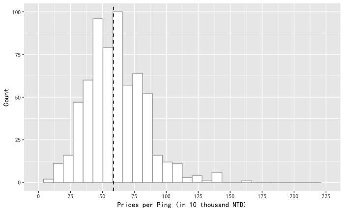

```r
library(ggplot2)
# Plot a histogram of prices per ping
ggplot(df.2017.sim, aes(UPRICE)) +
  geom_histogram(col = "darkgrey", fill = "white") +
  geom_vline(aes(xintercept = median(UPRICE)), col = "black", linetype = "dashed", size = 0.6) +
  scale_x_continuous(breaks = seq(0, 225, 25), limits = c(0, 225)) +
  labs(x = "Prices per Ping (in 10 thousand NTD)", y = "Count") +
  theme(text = element_text(family = "SimHei"), legend.position = "bottom")
```

When we look at the numbers of transactions, Zhongshan District (中山區) narrowly comes out on top, and a large portion of its transactions were located in commercial zones.

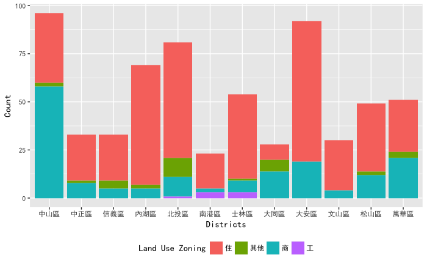

```r
# Plot the numbers of transactions among Taipei City districts
ggplot(df.2017.sim, aes(DISTRICT)) +
  geom_bar(aes(fill = LANDA_Z)) +
  labs(x = "Districts", y = "Count", fill = "Land Use Zoning") +
  theme(text = element_text(family = "SimHei"), legend.position = "bottom")
```

However, the ever prestigious Daan District (大安區) still ranked above others in terms of median price per *ping*.

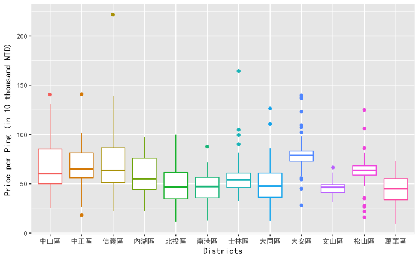

```r
# Plot the prices per ping among Taipei City districts
ggplot(df.2017.sim, aes(x = DISTRICT, y = UPRICE, col = DISTRICT)) +
  geom_boxplot() +
  labs(x = "Districts", y = "Price per Ping (in 10 thousand NTD)") +
  guides(col = FALSE) +
  theme(text = element_text(family = "SimHei"))
```

And as suspected, when friends, family members, relatives, or colleagues are involved in the transaction, the buyers appear to have gotten a sweet discount, as indicated by nearly all the medians of the green boxes falling markedly below those of the red ones. In fact, many of the green boxes are lower than and don’t even overlap with their red counterparts.

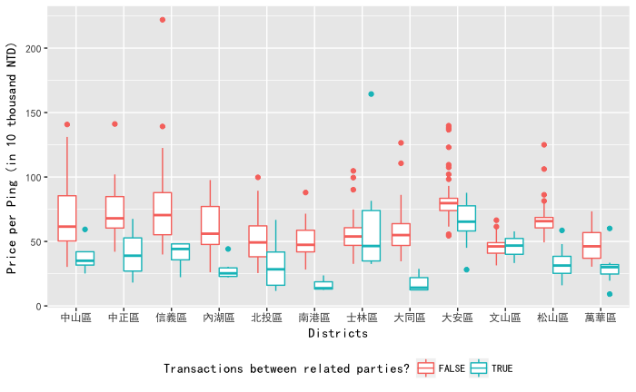

```r
# Highlight the differences in prices per ping due to transactions between related parties
ggplot(df.2017.sim, aes(x = DISTRICT, y = UPRICE, col = RMNOTE)) +
  geom_boxplot() +
  labs(x = "Districts", y = "Price per Ping (in 10 thousand NTD)", col = "Transactions between related parties?") +
  theme(text = element_text(family = "SimHei"), legend.position = "bottom")
```

Not only did pre-sale units appear to fetch median prices per *ping* somewhat higher than outright sales, the majority of their prices were clustered remarkably tight.

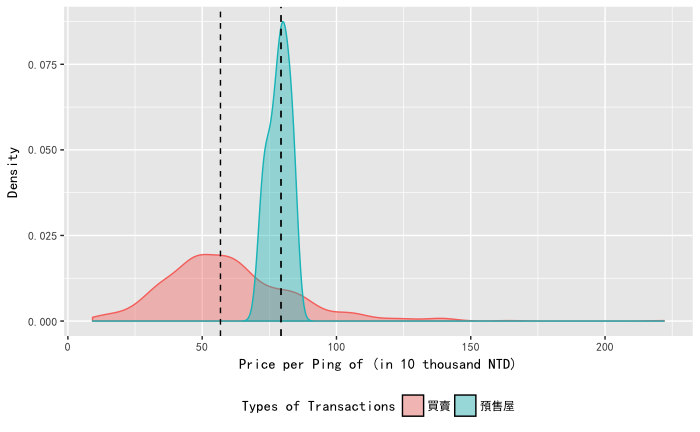

```r
# Create a density plot of the prices per ping for different types of transactions
ggplot(df.2017.sim, aes(x = UPRICE, col = CASE_T, fill = CASE_T)) +
  geom_density(alpha = 0.4) +
  geom_vline(aes(xintercept = median(df.2017[which(df.2017$CASE_T == "買賣"), ]$UPRICE)), col = "black", linetype = "dashed", size = 0.5) +
  geom_vline(aes(xintercept = median(df.2017[which(df.2017$CASE_T == "預售屋"), ]$UPRICE)), col = "black", linetype = "dashed", size = 0.6) +
  labs(x = "Price per Ping of (in 10 thousand NTD)", y = "Density", fill = "Types of Transactions") +
  guides(col = FALSE) +
  theme(text = element_text(family = "SimHei"), legend.position = "bottom")
```

Perhaps not surprisingly, the higher the floor number, the loftier the price per *ping*. Indeed, to enjoy that magnificent view of Taipei City’s scenic skyline, one has to pony up the extra cash.

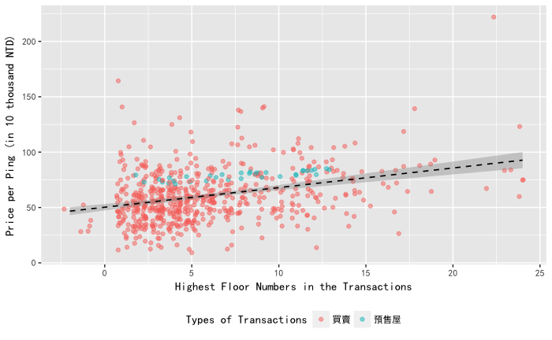

```r
# Plot prices per ping against highest floor numbers in the transactions
ggplot(df.2017.sim, aes(x = TOP.FL.NUM, y = UPRICE, col = CASE_T)) +
  geom_jitter(alpha = 0.5) +
  labs(x = "Highest Floor Numbers in the Transactions", y = "Price per Ping (in 10 thousand NTD)", col = "Types of Transactions") +
  geom_smooth(method = "lm", formula = y ~ x, se = TRUE, col = "black", linetype = "dashed", size = 0.6) +
  theme(text = element_text(family = "SimHei"), legend.position = "bottom")
```

The more recently a property was constructed, the higher the price per *ping* was. Besides reflecting the effect of depreciation, that upward trend in prices could have been partially due to the fact that a significant portion of the residential housing built within the past 2 decades included parking spaces as well.

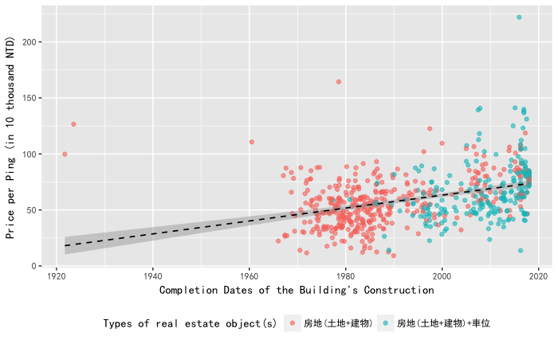

```r
# Plot prices per ping against completion dates of building constructions
ggplot(df.2017.sim, aes(x = FDATE, y = UPRICE, col = CASE_F)) +
  geom_point(alpha = 0.6) +
  labs(x = "Completion Dates of the Building's Construction", y = "Price per Ping (in 10 thousand NTD)", col = "Types of real estate object(s)") +
  geom_smooth(method = "lm", formula = y ~ x, se = TRUE, col = "black", linetype = "dashed", size = 0.6) +
  theme(text = element_text(family = "SimHei"), legend.position = "bottom")
```

## Predictive modeling

For our modeling, the response variable is the `UPRICE` variable, i.e. price per *ping* (in 10 thousand NTD).

In the following, we will go through 4 major tree-based machine learning techniques for predictive modeling, and see which one performs best.

- Regression trees
- Bagged trees
- Random Forests
- Boosted trees

### Regression trees

Now let’s start with the regression tree modeling.

```r
library(rpart)
library(rpart.plot)
# Set the seed number for reproducibility
set.seed(369)
# Randomly assign rows to ids (1, 2, and 3 represent the training, validation, and test tests respectively)
assignment <- sample(1:3, nrow(df.2017.sim), prob = c(0.7, 0.15, 0.15), replace = TRUE)
# Generate a training, validation, and test set from our original data frame
tree.train <- df.2017.sim[assignment == 1, ]
tree.validate <- df.2017.sim[assignment == 2, ]
tree.test <- df.2017.sim[assignment == 3, ]
# Train the tree-based model
tree.model <- rpart(formula = UPRICE ~ .,
                    data = tree.train,
                    method = "anova")
# Look at the model output
print(tree.model)
```

```
n= 429

node), split, n, deviance, yval
      * denotes terminal node

 1) root 429 236494.7000  60.50841
   2) FDATE< 12231.5 258 108099.4000  52.06140
     4) TPRICE< 1240 116  33266.4400  41.11147
       8) FAREA>=20.725 62   6025.4000  32.22355
        16) TPRICE< 615 9     67.7646  14.19000 *
        17) TPRICE>=615 53   2533.7380  35.28585 *
       9) FAREA< 20.725 54  16720.0600  51.31611
        18) DISTRICT=中山區,中正區,信義區,內湖區,北投區,士林區,大同區,萬華區 43   9527.2810  46.21860
          36) TPRICE< 331.5 9    504.6983  29.69111 *
          37) TPRICE>=331.5 34   5913.4020  50.59353 *
        19) DISTRICT=大安區,松山區 11   1707.6760  71.24273 *
     5) TPRICE>=1240 142  49562.5200  61.00641
      10) FAREA>=19.635 135  26958.8300  58.62133
        20) TPRICE< 2527.5 94  10729.2800  53.78351
          40) DISTRICT=內湖區,北投區,士林區,文山區,萬華區 45   2826.2040  48.17022 *
          41) DISTRICT=中山區,中正區,信義區,南港區,大同區,大安區,松山區 49   5183.0130  58.93857 *
        21) TPRICE>=2527.5 41   8985.5670  69.71293
          42) DISTRICT=信義區,內湖區,北投區,士林區,文山區,松山區,萬華區 21   4029.0750  62.22952 *
          43) DISTRICT=中山區,中正區,大安區 20   2545.6350  77.57050 *
      11) FAREA< 19.635 7   7025.0930 107.00430 *
   3) FDATE>=12231.5 171  82211.6900  73.25304
     6) DISTRICT=內湖區,北投區,南港區,士林區,大同區,文山區,萬華區 92  25651.4600  61.54446
      12) TPRICE< 3635.5 57  10509.7400  54.53018
        24) UPNOTE>=0.5 25   2973.7150  44.68160 *
        25) UPNOTE< 0.5 32   3216.7370  62.22437 *
      13) TPRICE>=3635.5 35   7770.1350  72.96771
        26) FDATE< 16265.5 21   4060.9840  66.13000 *
        27) FDATE>=16265.5 14   1254.5490  83.22429 *
     7) DISTRICT=中山區,中正區,信義區,大安區,松山區 79  29260.0500  86.88835
      14) TPRICE< 6165.5 64  11720.3100  81.17328
        28) UPNOTE>=0.5 8   1047.3690  63.70500 *
        29) UPNOTE< 0.5 56   7883.0850  83.66875 *
      15) TPRICE>=6165.5 15   6530.4430 111.27270 *
```

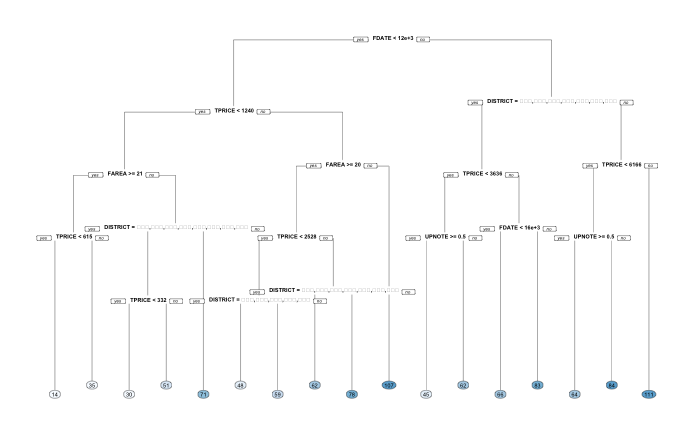

```r
# Plot the tree model
rpart.plot(x = tree.model, yesno = 2, type = 0, extra = 0)
```

With the model at hand, let’s see how good the model’s predictions are.

```r
library(Metrics)
# Generate predictions on the test set
tree.pred <- predict(object = tree.model,
                     newdata = tree.test)
# Compute the root mean square error (RMSE)
rmse(actual = tree.test$UPRICE,
     predicted = tree.pred)
```

```
[1] 16.23817
```

The model’s RMSE seems OK, but let’s run grid search to identify which hyper-parameters are likely to work best.

```r
# Establish a list of possible values for minsplit and maxdepth
minsplit <- seq(1, 25, 1)
maxdepth <- seq(1, 20, 1)
# Create a data frame containing all combinations
hyper.grid <- expand.grid(minsplit = minsplit, maxdepth = maxdepth)
# Create an empty list to store models
tree.grid.models <- list()
# Train the grid of models
for(i in 1:nrow(hyper.grid)){
  minsplit <- hyper.grid$minsplit[i]
  maxdepth <- hyper.grid$maxdepth[i]
  tree.grid.models[[i]] <- rpart(formula = UPRICE ~ .,
                                 data = tree.train,
                                 method = "anova",
                                 minsplit = minsplit,
                                 maxdepth = maxdepth)
}
# Create an empty vector to store RMSE
rmse.values <- c()
# Computer the RMSE for each model
for(i in 1:length(tree.grid.models)){
  tree.grid.pred <- predict(object = tree.grid.models[[i]],
                            newdata = tree.validate)
  rmse.values[i] <- rmse(actual = tree.validate$UPRICE,
                         predicted = tree.grid.pred)
}
# Identify the model with the lowest validation set RMSE
tree.grid.best.model <- tree.grid.models[[which.min(rmse.values)]]
# Print out the model parameters of the best model
print(tree.grid.best.model$control)
```

```
$minsplit
[1] 17

$minbucket
[1] 6

$cp
[1] 0.01

$maxcompete
[1] 4

$maxsurrogate
[1] 5

$usesurrogate
[1] 2

$surrogatestyle
[1] 0

$maxdepth
[1] 5

$xval
[1] 10
```

```r
# Compute test set RMSE on the best model
tree.best.model.pred <- predict(object = tree.grid.best.model,
                                newdata = tree.test)
rmse(actual = tree.test$UPRICE,
     predicted = tree.best.model.pred)
```

```
[1] 16.84563
```

Surprisingly, the best model from our grid search produces a RMSE of 16.846, which is higher than our initial regression tree model’s RMSE of 16.238.

### Bagged trees

While the simple decision tree modeling above may be easy to implement and produces results straightforward to interpret, it tends to suffer from bigger variances (and hence lower prediction power).

Thus, we’ll go through 3 popular ensemble methods, i.e. bagged trees, Random Forests, and boosted trees, all of which combine multiple decision trees in different ways to squeeze additional prediction accuracy out of predictive algorithms.

Bagging is an ensembling technique in which multiple independent models/predictors are built on random bootstrapped samples and combined with some model averaging methods (e.g. weighted average, majority vote, arithmetic mean).

Let’s start with bagged tree modeling.

```r
library(ipred)
# Train a bagged model
bag.model <- bagging(formula = UPRICE ~ .,
                     data = tree.train,
                     coob = TRUE)
# Compute test set RMSE on the bagged model
bag.model.pred <- predict(object = bag.model,
                          newdata = tree.test)
rmse(actual = tree.test$UPRICE,
     predicted = bag.model.pred)
```

```
[1] 15.05328
```

The bagged tree model’s RMSE is 15.053, which is lower than that of our initial regression tree model.

### Random Forests

Let’s try a modified version of the bagged tree modeling, i.e. Random Forests. Like the bagged tree modeling earlier on, Random Forests also trains on bootstrapped samples of the training set. The key difference lies in the fact that when training the trees that make up the ensemble, the Random Forests algorithms add a bit extra randomness to the model; at each split in the tree, rather than considering all the input variables for the split, only a random subset of these variables are used as candidates for the split.

Adding this additional level of randomness leads to a collection of trees that are less correlated and hence better model performance. In other words, Random Forests improves upon bagged tree modeling by reducing correlation between sampled trees (albeit at the expense of lower interpretability).[^2]

Let’s begin the Random Forests modeling.

```r
library(randomForest)
# Set the seed number for reproducibility
set.seed(222)
# Train a Random Forest
rf.model <- randomForest(formula = UPRICE ~ .,
                         data = tree.train,
                         importance = TRUE)
# Print out the model results
print(rf.model)
```

```
Call:
 randomForest(formula = UPRICE ~ ., data = tree.train, importance = TRUE)
               Type of random forest: regression
                     Number of trees: 500
No. of variables tried at each split: 10

          Mean of squared residuals: 184.4272
                    % Var explained: 66.55
```

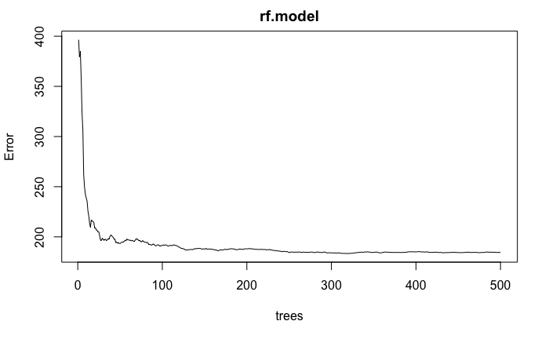

```r
# Plot the error vs. number of trees graph
plot(rf.model)
```

The plot above shows how the error falls as more sampled trees are added.

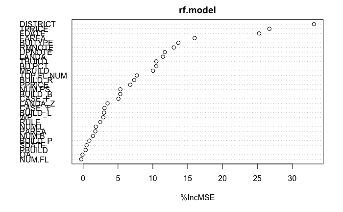

```r
# Plot dotplots of variable importance
varImpPlot(rf.model, type = 1)
```

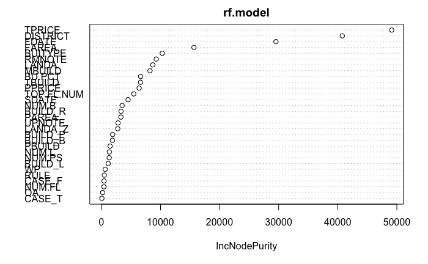

```r
varImpPlot(rf.model, type = 2)
```

```r
# Compute test set RMSE on the Random Forests model
rf.model.pred <- predict(object = rf.model,
                          newdata = tree.test)
rmse(actual = tree.test$UPRICE,
     predicted = rf.model.pred)
```

```
[1] 14.39579
```

Our Random Forests model just beat all the other models above with an even lower RMSE of 14.396. Good job!

Still, let’s see if we can get a better model by tuning the model.

```
mtry = 10  OOB error = 182.3212
Searching left ...
mtry = 5    OOB error = 201.2051
-0.1035751 0.05
Searching right ...
mtry = 20   OOB error = 165.1625
0.0941126 0.05
mtry = 30   OOB error = 156.768
0.0508255 0.05
```

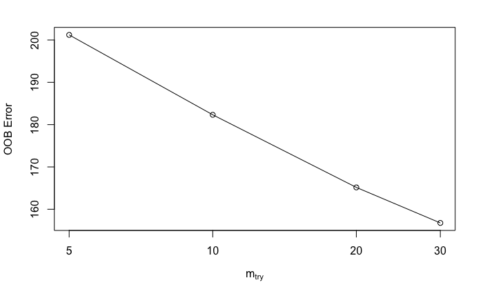

```r
# Set the seed number for reproducibility
set.seed(111)
# Tune the Random Forests model
tune.rf <- tuneRF(x = subset(tree.train, select = -UPRICE),
              y = tree.train$UPRICE,
              ntreeTry = 500)
```

```r
# Print out the result
print(tune.rf)
```

```
   mtry OOBError
5     5 201.2051
10   10 182.3212
20   20 165.1625
30   30 156.7680
```

To minimize the out-of-bag error, the optimal number of variables to be randomly sampled as candidates at each split (i.e. mtry) is 30.

Let’s put this to work.

```r
# Set the seed number for reproducibility
set.seed(999)
# Train a tuned Random Forests model using the optimal number of variables to be randomly sampled
rf.model.mtry <- randomForest(formula = UPRICE ~ .,
                              data = tree.train,
                              importance = TRUE,
                              mtry = tune.rf[which.min(tune.rf[, "OOBError"]), "mtry"])
# Compute test set RMSE on the tuned Random Forests model
rf.model.mtry.pred <- predict(object = rf.model.mtry,
                              newdata = tree.test)
rmse(actual = tree.test$UPRICE,
     predicted = rf.model.mtry.pred)
```

```
[1] 13.9443
```

The tuning was effective in further lowering the RMSE down to 13.944. For such a quick and easy tuning, not a bad improvement at all!

### Boosted trees

Similar to bagging, boosting is also an ensemble technique in which many models/predictors are built on bootstrapped samples. However, the models/predictors in boosting are not independent in the sense that new predictors learn from the mistakes from their previous predictors and that observations with higher error have higher probabilities of occurring in subsequent models. Each model is focused on accurately predicting the observations where the prior model performs poorly.

Put differently, whereas bagging can be thought of as a *parallel* process in which independent models are built and then combined in some fashion, boosting is a *sequential* process in which each model tries to correct for the mistakes of the combined boosted ensemble of all previous models in an additive manner.

For boosted tree modeling, we will focus specifically on arguably its most popular variant in recent years, i.e. Gradient Boosting Machine (GBM). GBM builds upon the Adaptive Boosting (or AdaBoost) method, repetitively leveraging the patterns in residuals of the whole ensemble learned so far for new modeling training to achieve higher accuracy results.

```r
library(gbm)
# Convert several columns into factor type
for(i in 1:ncol(tree.train)){
  if(class(tree.train[, i]) == "logical"){
    tree.train[, i] <- as.factor(tree.train[, i])
  } else if(class(tree.train[, i]) == "Date"){
    tree.train[, i] <- factor(tree.train[, i], ordered = TRUE)
  }
}
# Train a GBM model
gbm.model <- gbm(formula = UPRICE ~ .,
                 distribution = "gaussian",
                 data = tree.train,
                 n.trees = 50000)
# Print out the results
print(gbm.model)
```

```
gbm(formula = UPRICE ~ ., distribution = "gaussian", data = tree.train,
    n.trees = 50000)
A gradient boosted model with gaussian loss function.
50000 iterations were performed.
There were 30 predictors of which 26 had non-zero influence.
```

|  | var | rel.inf |
| --- | --- | --- |
| TPRICE | TPRICE | 3.106240e+01 |
| DISTRICT | DISTRICT | 1.738417e+01 |
| FAREA | FAREA | 1.427956e+01 |
| FDATE | FDATE | 7.925985e+00 |
| MBUILD | MBUILD | 6.379368e+00 |
| RMNOTE | RMNOTE | 4.405948e+00 |
| TOP.FL.NUM | TOP.FL.NUM | 2.676563e+00 |
| BUITYPE | BUITYPE | 2.594283e+00 |
| PPRICE | PPRICE | 2.120617e+00 |
| BUILD_P | BUILD_P | 1.678227e+00 |

[output cut: 20 more lines]

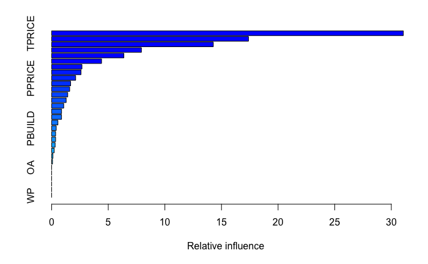

```r
# Print out the table of variable importance
summary(gbm.model)
```

Hyperparameter tuning is especially important to GBM, which is prone to overfitting. Here, we’ll search for the optimal number of trees.

```
OOB generally underestimates the optimal number of iterations although predictive performance is reasonably competitive. Using cv.folds>0 when calling gbm usually results in improved predictive performance.
```

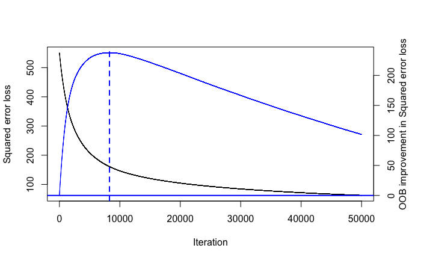

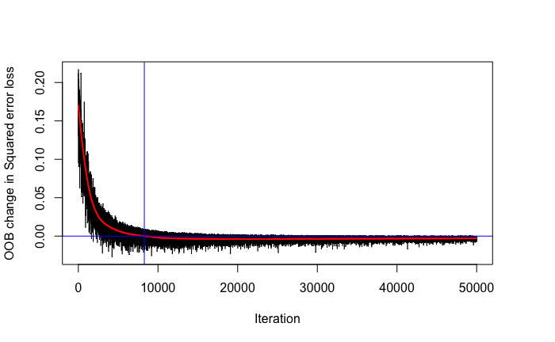

```r
# Get the optimal ntree estimate based on out-of-bag samples
ntree.opt.oob <- gbm.perf(object = gbm.model,
                          method = "OOB",
                          oobag.curve = TRUE)
```

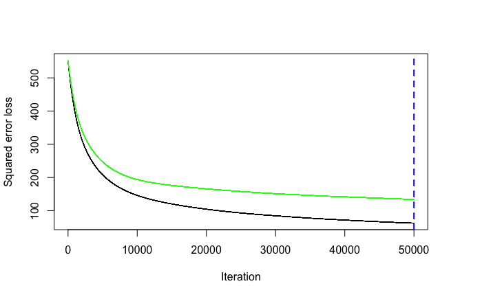

```r
# Set the seed number for reproducibility
set.seed(999)
# Train a cross-validated GBM model
gbm.model.cv <- gbm(formula = UPRICE ~ .,
                    distribution = "gaussian",
                    data = tree.train,
                    n.trees = 50000,
                    cv.folds = 5)
# Get the optimal ntree estimate based on cross validation
ntree.opt.cv <- gbm.perf(object = gbm.model.cv,
                         method = "cv")
```

We then use the optimal number of trees for both methods to compute the RMSE.

```r
# Compute test set RMSE on the GBM model using 2 different number of trees
gbm.model.oob.pred <- predict(object = gbm.model,
                              newdata = tree.test,
                              n.trees = ntree.opt.oob)
gbm.model.cv.pred <- predict(object = gbm.model,
                              newdata = tree.test,
                              n.trees = ntree.opt.cv)
rmse(actual = tree.test$UPRICE,
     predicted = gbm.model.oob.pred)
```

```
[1] 16.61152
```

```r
rmse(actual = tree.test$UPRICE,
     predicted = gbm.model.cv.pred)
```

```
[1] 14.38075
```

The ntree estimate based on the cross validation method gave us a lower RSME of 14.381 than that of the out-of-bag sampling method, which again confirms that the latter tends to underestimate the optimal number of iterations.

Our GBM model produced a respectably low RMSE, but still failed to measure up to that of the tuned Random Forests model.

Therefore, at least for our current investigation, the tuned Random Forests model emerges as the best performing predictive model.

## Conclusions

A quick summary of our analysis:

- The tuned Random Forests model performed best among all models with the lowest RMSE.
- Our regression tree model, Random Forests model, and GBM model all consistently underscore `DISTRICT` (the districts of the properties), `TPRICE` (total transaction prices), `FDATE` (completion dates of the building constructions), and `FAREA` (numbers of *ping* in the buildings transferred) as the 4 most important variables in predicting the prices per *ping* for Taipei City’s residential housing.

What is noteworthy is that even though the results of our analysis placed Random Forests as the top choice of modeling, this by no means suggests GBM is conclusively inferior for the goal of this analysis.

The RMSE of our GBM model already came close to that of the tuned Random Forests model, so if we had also tweaked some other hyperparameters in our GBM model (e.g. shrinkage, minimum number of observations in the tree terminal nodes, maximum nodes per tree, etc.), it would probably have achieved a very similar–or even better–performance.

```
 setting  value
 version  R version 3.4.2 (2017-09-28)
 system   x86_64, darwin15.6.0
 ui       RStudio (1.1.423)
 language (EN)
 collate  en_US.UTF-8
 tz       <NA>
 date     2018-02-11
```

```
Packages ---------------------------------------------------------------------------
```

[output not shown]

[output cut: 17 more lines]

```
 rprojroot      1.3-2   2018-01-03 CRAN (R 3.4.2)
 rvest          0.3.2   2016-06-17 CRAN (R 3.4.0)
 scales         0.5.0   2017-08-24 CRAN (R 3.4.1)
 splines      * 3.4.2   2017-10-04 local
 stats        * 3.4.2   2017-10-04 local
 stringi        1.1.6   2017-11-17 CRAN (R 3.4.2)
 stringr      * 1.2.0   2017-02-18 CRAN (R 3.4.0)
 survival     * 2.41-3  2017-04-04 CRAN (R 3.4.2)
 tibble         1.4.2   2018-01-22 CRAN (R 3.4.3)
 tools          3.4.2   2017-10-04 local
 utils        * 3.4.2   2017-10-04 local
 viridisLite    0.3.0   2018-02-01 CRAN (R 3.4.2)
 withr          2.1.1   2017-12-19 CRAN (R 3.4.3)
 xml2           1.2.0   2018-01-24 CRAN (R 3.4.3)
 yaml           2.1.16  2017-12-12 CRAN (R 3.4.3)
```

> *[Back to my GitHub Pages](https://roywangtw.github.io/)*
[^1]: Aside from the temporal proximity and thus greater relevance, another main reason why we decide to use data solely from 2017 is the fact that it was the only year in the Data.Taipei XML file with over 500 transaction records. In contrast, 2012, 2013, 2014, 2015, and 2016 came with a paltry 8, 22, 55, 8, and 4 records respectively.
[^2]: For more details on Random Forests, please refer to [this article](http://www.listendata.com/2014/11/random-forest-with-r.html).